# Homework 03

Ridge regression, optimization, and model selection

This report uses Python, NumPy’s `default_rng(43231)`, and the supplied data and fold assignments. All standardization uses variance with divisor equal to the fitting sample size. Intercepts are unpenalized. AI assisted with the skill, derivations, code, and written answers. The supplied `solutions-03.qmd` was not used.

## Question 1: An explanation skill

I developed `explain-to-me/SKILL.md` to explain a question’s purpose and required work without giving the answer. It is installed locally at `C:/Users/zm25/.codex/skills/explain-to-me/`. The skill passed the skill creator’s frontmatter and naming validation. Its separate `agents/openai.yaml` contains:

```yaml
policy:
  allow_implicit_invocation: false
```

This keeps the skill scoped to explicit requests. Installation copied the local skill folder into the personal skills directory; a GitHub download was unnecessary for this locally created skill. The complete skill file appears at the end of this report.

### Local explanation test on Question 2

The following is a local, manual application of the installed instructions, using the test prompt **“Use `explain-to-me` to read and explain Question 2.”** It is not a claim that a separate user turn or automatic discovery test has occurred. The installed skill will be available for explicit invocation on the next turn.

**NoteExplanation produced by applying the skill**

Question 2 asks you to compare how OLS and two ridge penalties behave when two predictors carry almost the same information. The main distinction is between estimating individual slopes reliably and predicting the response reliably.

Keep the standardized predictor matrix fixed. Its columns must have mean zero and average squared value one. The vector $\boldsymbol\mu$ is the noise-free response at those fixed predictor values. The two noise vectors create a training response and an independent test response at the same design points.

For part (a), report the first two predictors’ correlation and the largest and smallest singular values, then connect them to the stability of the sum and difference of the first two slopes. For part (b), run 200 repetitions and report means and sample standard deviations of the four requested coefficient quantities, plus average training and test MSE for each penalty. Draw a fresh pair of noise vectors in each repetition and reuse that pair for all penalties. For part (c), explain the bias–variance tradeoff and why changes in individual coefficients need not produce comparable changes in fitted responses.

Remember to add the training response mean back to every prediction; do not center test responses using their own mean. The relevant lecture sections are “A controlled experiment: stability under correlation,” “Stable and unstable coefficient directions,” and “Does greater stability improve prediction?” in [Ridge Regression: Stability Through Shrinkage](https://teazrq.github.io/stat432rpy/topics/ridge-regression/ridge-regression.html).

Guiding question: Why should all three penalties use the same training and test noise in a given repetition?

The explanation identifies the goal, deliverables, fixed design, varying responses, and procedural pitfalls. It provides neither numerical answers nor solution code. A subsequent explicit invocation can check discovery in a new turn; the local test above checks the behavior of the written instructions. The remaining sections solve the assignment under the separate request to complete the homework.

## Question 2: Nearly collinear predictors

### (a) Design and unstable directions

I generated the five independent normal vectors in the order $L,U_1,U_2,X_3,X_4$, constructed the four columns, and standardized each using

$$X_{ij}=\frac{X^{\mathrm{raw}}_{ij}-\bar X^{\mathrm{raw}}_j}
{\sqrt{n^{-1}\sum_i(X^{\mathrm{raw}}_{ij}-\bar X^{\mathrm{raw}}_j)^2}}.$$

The fixed design gives

| Quantity | Value |
| --- | --- |
| $\operatorname{cor}(X_1,X_2)$ | 0.998333 |
| Largest singular value | 14.172962 |
| Smallest singular value | 0.406094 |

Let $s=\beta_1+\beta_2$ and $\delta=\beta_1-\beta_2$. Their contribution to the mean response is

$$X_1\beta_1+X_2\beta_2
=\frac{X_1+X_2}{2}s+\frac{X_1-X_2}{2}\delta.$$

Since the standardized columns nearly agree, $X_1-X_2$ is short, whereas $X_1+X_2$ is long. More precisely,

$$\|X_1-X_2\|^2=2n(1-r),\qquad
\|X_1+X_2\|^2=2n(1+r).$$

Here those squared lengths are approximately $0.333497$ and $399.666503$. In the two-column problem, the ratio of the variance of the estimated difference to that of the estimated sum is $(1+r)/(1-r)\approx1198.41$. The other two predictors modify that exact ratio, but the nearly unidentified difference direction remains.

With noise variance one, the OLS covariance is $(X^{\mathsf T}X)^{-1}$. Its variance in a right singular-vector direction is $1/d_j^2$; the extreme variances are about $6.06384$ and $0.004978$. Thus a direction close to the first-slope difference amplifies noise far more than the well-identified sum direction.

### (b) Simulation results

I used the first response pair as repetition 1 and generated 199 further pairs, for 200 fits per penalty in total. Each repetition uses the same realized training/test pair for all three penalties. The intercept is always the training mean, and empirical standard deviations use divisor $199$.

| lambda | quantity | mean | sd |
| --- | --- | --- | --- |
| 0.000000 | beta1 | 1.290103 | 1.795135 |
| 0.000000 | beta2 | 1.701421 | 1.797916 |
| 0.000000 | sum | 2.991524 | 0.104908 |
| 0.000000 | difference | -0.411319 | 3.591520 |
| 0.020000 | beta1 | 1.464518 | 0.144652 |
| 0.020000 | beta2 | 1.496776 | 0.147926 |
| 0.020000 | sum | 2.961294 | 0.103896 |
| 0.020000 | difference | -0.032258 | 0.273530 |
| 0.200000 | beta1 | 1.355268 | 0.049432 |
| 0.200000 | beta2 | 1.359321 | 0.050405 |
| 0.200000 | sum | 2.714589 | 0.095437 |
| 0.200000 | difference | -0.004054 | 0.029327 |

The true values of `beta1`, `beta2`, `sum`, and `difference` are $1.5$, $1.5$, $3$, and $0$, respectively. Averaging each repetition’s MSE gives:

| lambda | training MSE | test MSE |
| --- | --- | --- |
| 0.000000 | 0.949265 | 1.038398 |
| 0.020000 | 0.959724 | 1.029182 |
| 0.200000 | 1.063901 | 1.125260 |

### (c) Bias, variance, and fitted values

OLS has large variation in the individual slopes: their empirical standard deviations are about $1.80$, and the difference has standard deviation $3.59$. Yet their sum has standard deviation only $0.105$. The empirical OLS difference mean of $-0.411$ is Monte Carlo variation, not evidence of theoretical OLS bias: its Monte Carlo standard error is approximately $3.592/\sqrt{200}=0.254$.

At $\lambda=0.02$, the difference standard deviation falls to $0.274$, while the sum’s mean changes modestly from $2.992$ to $2.961$. The average test MSE falls slightly, from $1.0384$ to $1.0292$. Ridge suppresses the high-variance difference direction, but that direction already has little effect on predictions because it multiplies the short vector $X_1-X_2$. Consequently, coefficient stability can improve dramatically while fitted values and prediction accuracy change much less.

At $\lambda=0.2$, the difference is even more stable, but the sum is shrunk to a mean of $2.715$ rather than $3$. Shrinkage of predictive directions introduces enough bias to increase the average test MSE to $1.1253$. OLS has the smallest training MSE because it minimizes the unpenalized training residual sum of squares; that does not guarantee the best test MSE.

For a conditional check, write $H_\lambda=X(X^{\mathsf T}X+n\lambda I)^{-1}X^{\mathsf T}$. Since the design is centered, the expected independent-test MSE at this design is

$$1+\frac{\|(H_\lambda-I)\mu\|^2}{n}
+\frac{1+\operatorname{tr}(H_\lambda^2)}{n}.$$

The first term is irreducible test noise, the second is squared prediction bias, and the last is prediction variance, including $1/n$ from the estimated intercept.

| lambda | squared prediction bias | prediction variance | expected test MSE |
| --- | --- | --- | --- |
| 0.000000 | 0.000000 | 0.050000 | 1.050000 |
| 0.020000 | 0.001309 | 0.039067 | 1.040376 |
| 0.200000 | 0.104191 | 0.032068 | 1.136260 |

These exact conditional risks support the simulation’s pattern; the empirical averages need not equal them after only 200 repetitions.

## Question 3: What ridge shrinks

### (a) Normal equations and uniqueness

Differentiating with respect to the slope vector gives

$$\nabla L_\lambda(\beta)
=-\frac1nX^{\mathsf T}(\widetilde y-X\beta)+\lambda\beta.$$

Setting the gradient to zero and multiplying by $n$ gives

$$(X^{\mathsf T}X+n\lambda I_p)\widehat\beta_\lambda
=X^{\mathsf T}\widetilde y.$$

For any nonzero $v\in\mathbb R^p$ and $\lambda>0$,

$$v^{\mathsf T}(X^{\mathsf T}X+n\lambda I_p)v
=\|Xv\|^2+n\lambda\|v\|^2>0.$$

The matrix is positive definite and invertible, and the objective is strictly convex. Therefore the stationary point is the unique global minimizer, even if $X$ is rank deficient or $p>n$. No unit-variance scaling assumption is needed for this argument.

### (b) Singular directions and effective degrees of freedom

For the compact SVD $X=U_rD_rV_r^{\mathsf T}$, the ridge solution is

$$\widehat\beta_\lambda
=V_r\operatorname{diag}\left(\frac{d_j}{d_j^2+n\lambda}\right)
U_r^{\mathsf T}\widetilde y.$$

For $\lambda>0$, all coefficient components in the null space of $X$ are zero. Multiplying by $X$ yields

$$X\widehat\beta_\lambda
=\sum_{j=1}^r u_j\frac{d_j^2}{d_j^2+n\lambda}
(u_j^{\mathsf T}\widetilde y).$$

OLS projects onto the column space of $X$, retaining each component $u_j^{\mathsf T}\widetilde y$. Ridge multiplies that component by $\rho_j=d_j^2/(d_j^2+n\lambda)$. For $n\lambda=100(0.01)=1$:

| Direction | $d_j$ | $\rho_j$ |
| --- | --- | --- |
| 1 | 10 | $100/101=0.990099$ |
| 2 | 2 | $4/5=0.800000$ |
| 3 | 0.2 | $0.04/1.04=1/26=0.038462$ |

Because centered predictors are orthogonal to the constant vector, the full response smoother is $\mathbf1\mathbf1^{\mathsf T}/n+H_\lambda$. Its trace is

$$\operatorname{df}_{\mathrm{eff}}
=1+\frac{100}{101}+\frac45+\frac1{26}
=\boxed{2.828561}.$$

### (c) Prediction variance and bias

Direction 3 receives the strongest shrinkage: only about $3.85\%$ of its OLS fitted-response component remains. If the noise has covariance $\sigma^2I$, then $u_j^{\mathsf T}\widetilde y$ has variance $\sigma^2$ in these centered directions. Ridge reduces the variance of that fitted component to $\rho_j^2\sigma^2$. In direction 3 this is about $0.001479\sigma^2$, compared with $\sigma^2$ under OLS.

If the true centered mean has a large component $\theta_j=u_j^{\mathsf T}\mu$ in that direction, however, shrinkage introduces bias $(\rho_j-1)\theta_j$, with squared contribution $(1-\rho_j)^2\theta_j^2$. A small singular value alone does not imply negligible signal: a sufficiently large true slope component along the corresponding right singular vector can still make $\theta_j=d_jv_j^{\mathsf T}\beta$ large. Strong shrinkage would then sacrifice useful signal.

## Question 4: Optimization

### (a) Condition numbers and objective geometry

For a symmetric positive definite matrix, the spectral condition number is its largest eigenvalue divided by its smallest. Thus

$$\kappa(A_0)=\frac9{0.01}=\boxed{900},\qquad
\kappa(A_{0.09})=\frac{9.09}{0.10}=\boxed{90.9}.$$

Adding ridge increases both eigenvalues equally, so it raises the weak curvature proportionally much more. The contours become less elongated: the long-to-short axis ratio is $\sqrt{\kappa}$, falling from $30$ to approximately $9.534$. The objective is easier to optimize with a common step size across directions, although its minimizer has also changed.

### (b) Gradient-descent error dynamics

Let $b=X^{\mathsf T}\widetilde y/n$. The gradient is $A_\lambda\beta-b$, and the minimizer satisfies $A_\lambda\widehat\beta_\lambda=b$. Therefore

$$e^{(k+1)}=(I-\eta A_\lambda)e^{(k)}.$$

An eigenvector of $A_0$ with eigenvalue $a$ is also an eigenvector of $A_\lambda$ with eigenvalue $a+\lambda$. Its scalar error component obeys

$$e_a^{(k+1)}=\{1-\eta(a+\lambda)\}e_a^{(k)}.$$

Every direction contracts precisely when $|1-\eta(a+\lambda)|<1$ for both eigenvalues, giving the open interval

$$\boxed{0<\eta<\frac2{9.09}\approx0.220022}.$$

At $\eta=1/M=1/9.09\approx0.110011$, the factors are

$$1-\frac{9.09}{9.09}=0,\qquad
1-\frac{0.10}{9.09}=\frac{899}{909}\approx0.988999.$$

The high-curvature direction is eliminated after one update in exact arithmetic. The low-curvature direction retains about $98.9\%$ of its error per step and converges slowly.

At $\eta=2.1/M\approx0.231023$, the factors are

$$1-2.1=-1.1,\qquad
1-\frac{2.1(0.10)}{9.09}\approx0.976898.$$

The high-curvature component alternates sign and grows in magnitude by a factor of $1.1$ each step. Under the stated nonzero initial component, the method diverges, even though the low-curvature component contracts.

### (c) Numerical speed is not a tuning rule

Larger $\lambda$ improves the condition number, but also changes the statistical target. As $\lambda\to\infty$, all slopes approach zero and predictions approach the training response mean. This can be easy to optimize yet have substantial prediction bias. Choose $\lambda$ using a criterion for generalization, such as properly nested preprocessing within CV or GCV, and choose the optimization method and step size to solve that selected objective accurately. Faster optimization alone measures neither predictive accuracy nor the quality of the bias–variance tradeoff.

## Question 5: Real-estate prediction

### (a) Ten-fold cross-validation

I joined the files by the unique `row_id`, verified the 332/82 training/test split, and excluded `row_id`, `split`, and `cv_fold` from the predictors. The six quantitative predictors are `date`, `age`, `distance`, `stores`, `latitude`, and `longitude`. The training fold sizes are 34, 34, and eight folds of 33.

For each held-out fold, predictor means and population standard deviations and the response mean were estimated from the other nine folds. With $m$ fitting observations, the slopes solve $(Z^{\mathsf T}Z+m\lambda I)\widehat\beta=Z^{\mathsf T}(y-\bar y)$. Validation predictions use those same fitting means and scales and add that fitting response mean. Thus validation observations affect neither standardization nor fitting.

I evaluated all 122 grid values, including OLS. The CV criterion is the **unweighted mean of the ten fold MSEs**, as requested, and the SE is their sample standard deviation divided by $\sqrt{10}$. The selections are

$$\boxed{\lambda_{\min}=10^{-1.7}=0.0199526231},$$

$$\overline{\operatorname{MSE}}(\lambda_{\min})=82.977649,
\qquad \operatorname{SE}(\lambda_{\min})=19.229914.$$

The one-SE cutoff is $82.977649+19.229914=102.207563$. Searching the entire candidate grid for the largest penalty at or below this cutoff gives

$$\boxed{\lambda_{\mathrm{1se}}=10^{0.2}=1.5848931925}.$$

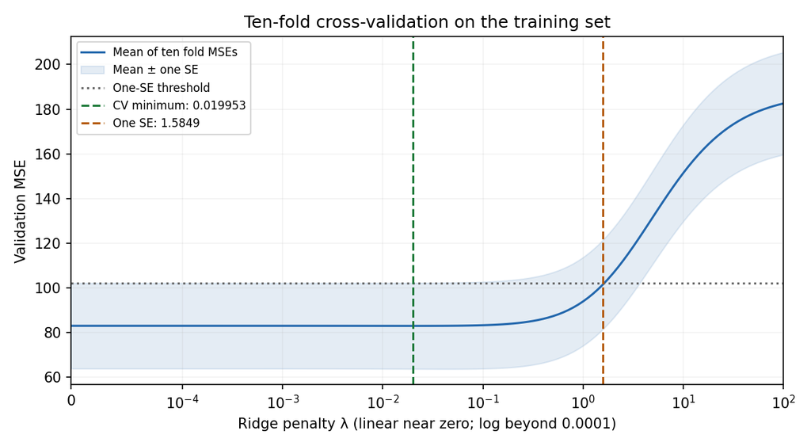

Mean validation MSE over the complete penalty grid. The shaded band uses the requested fold-based SE at each candidate; the horizontal line uses the SE only at the CV minimum. The axis includes the OLS candidate at zero.

The SE band is descriptive, not a confidence interval with guaranteed coverage: the training sets overlap across folds. The one-SE rule is the conventional heuristic requested in the question.

### (b) Generalized cross-validation

I recomputed the predictor means and scales using all 332 training observations and kept them fixed across the GCV path. If $s_j$ are the eigenvalues of $Z^{\mathsf T}Z$, then

$$\operatorname{df}_{\mathrm{eff}}(\lambda)
=1+\sum_{j=1}^6\frac{s_j}{s_j+332\lambda},
\qquad
\operatorname{GCV}(\lambda)
=\frac{\operatorname{MSE}_{\mathrm{train}}(\lambda)}
{\{1-\operatorname{df}_{\mathrm{eff}}(\lambda)/332\}^2}.$$

The intercept contributes one degree of freedom. Minimization over the same grid gives

$$\boxed{\lambda_{\mathrm{GCV}}=10^{-1.55}=0.0281838293},
\qquad \operatorname{GCV}_{\min}=83.501914.$$

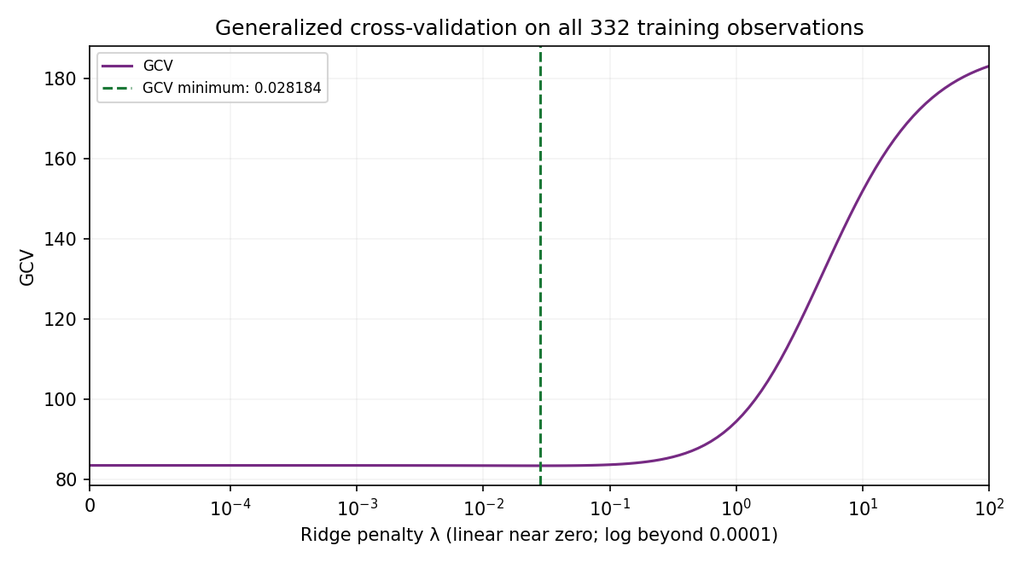

GCV over the complete penalty grid, including zero, with its selected penalty marked.

### (c) Final evaluation after freezing the selections

The code fixes all three penalties before extracting the test-response vector. It then uses the fits on all training observations, with training means and scales, to evaluate the four models:

| model | lambda | training MSE | test MSE | effective df |
| --- | --- | --- | --- | --- |
| OLS | 0.000000 | 80.093917 | 66.322464 | 7.000000 |
| CV minimum | 0.019953 | 80.135429 | 65.999575 | 6.773213 |
| One SE | 1.584893 | 100.373559 | 81.199810 | 3.032870 |
| GCV minimum | 0.028184 | 80.171254 | 65.902765 | 6.688657 |

OLS uses all seven degrees of freedom, including the intercept. CV and GCV select small positive penalties with effective degrees of freedom near $6.7$. Their training errors are slightly higher than OLS, while their observed test errors are slightly lower. These small differences are compatible with mild stabilization and should not be overstated from one test sample.

The one-SE model has only about $3.03$ effective degrees of freedom. The relatively large fold-based SE permits much stronger shrinkage. In this split that simpler model has appreciably higher training and test error, consistent with too much shrinkage of predictive signal. The one-SE heuristic favors simplicity within its tolerance; it does not guarantee the lowest test error.

GCV has the smallest observed test MSE in this table, but selecting it *because* of that result would reuse the test set for tuning. The test set would then cease to be an independent evaluation of the selection procedure and the chosen test error would be optimistically biased. The selection rule must be fixed from training data; any further comparison or tuning requires training-only validation or a new independent test set. The test MSE being below the training MSE here is possible because the test and training sets contain different observations.

## Reproducible workflow

From `homework/week-03/`, run:

```bash
python analysis-03.py
python build-report-03.py
quarto render homework-03.qmd
```

The first script recreates the numerical tables, selection summary, and plots in `results/`; the second inserts them into this source. This report’s computational source is included below so that the self-contained HTML preserves the workflow. The CSV files supplied with the assignment are required to rerun Question 5. Computation uses NumPy, pandas, and Matplotlib. QMD rendering uses Quarto.

**NoteComplete numerical workflow**

```python
"""Reproduce Homework 03 numerical results without using the supplied solutions."""
from pathlib import Path
import json
import numpy as np
import pandas as pd
import matplotlib
matplotlib.use('Agg')
import matplotlib.pyplot as plt

ROOT = Path(__file__).resolve().parent
OUT = ROOT / 'results'
OUT.mkdir(exist_ok=True)
plt.rcParams.update({'figure.dpi': 150, 'font.size': 10})

# Question 2: one fixed design; paired noise across penalties in every repetition.
rng = np.random.default_rng(43231)
n = 100
L, U1, U2, X3, X4 = rng.standard_normal((5, n))
X = np.column_stack((L + .04 * U1, L + .04 * U2, X3, X4))
X = (X - X.mean(axis=0)) / X.std(axis=0, ddof=0)
beta = np.array([1.5, 1.5, 1., 0.])
mu = X @ beta
penalties = np.array([0., .02, .2])
operators = [np.linalg.solve(X.T @ X + n * lam * np.eye(4), X.T)
             for lam in penalties]
estimates = np.empty((200, 3, 4))
errors = np.empty((200, 3, 2))
for rep in range(200):
    y = mu + rng.standard_normal(n)
    ystar = mu + rng.standard_normal(n)
    for j, operator in enumerate(operators):
        b = operator @ (y - y.mean())
        fitted = y.mean() + X @ b
        estimates[rep, j] = [b[0], b[1], b[0] + b[1], b[0] - b[1]]
        errors[rep, j] = [np.mean((y - fitted)**2),
                          np.mean((ystar - fitted)**2)]
q2 = []
for j, lam in enumerate(penalties):
    for k, label in enumerate(['beta1', 'beta2', 'sum', 'difference']):
        q2.append({'lambda': lam, 'quantity': label,
                   'mean': estimates[:, j, k].mean(),
                   'sd': estimates[:, j, k].std(ddof=1)})
q2 = pd.DataFrame(q2)
q2_mse = pd.DataFrame({'lambda': penalties,
                       'training MSE': errors[:, :, 0].mean(axis=0),
                       'test MSE': errors[:, :, 1].mean(axis=0)})
singular = np.linalg.svd(X, compute_uv=False)
q2_design = {'correlation': np.corrcoef(X[:, 0], X[:, 1])[0, 1],
             'largest singular value': singular[0],
             'smallest singular value': singular[-1]}

# Conditional theoretical prediction risk, a check on the simulation.
q2_theory = []
for lam, operator in zip(penalties, operators):
    H = X @ operator
    bias2 = np.mean((H @ mu - mu)**2)
    variance = (1 + np.sum(H * H)) / n  # includes intercept variance
    q2_theory.append({'lambda': lam, 'squared prediction bias': bias2,
                      'prediction variance': variance,
                      'expected test MSE': 1 + bias2 + variance})

# Question 5: join by row_id, select penalties using training data only.
data = pd.read_csv(ROOT / 'data/realestate.csv')
assignments = pd.read_csv(ROOT / 'data/realestate-split-folds.csv')
assert data.row_id.is_unique and assignments.row_id.is_unique
assert set(data.row_id) == set(assignments.row_id)
merged = data.merge(assignments, on='row_id', validate='one_to_one')
predictors = ['date', 'age', 'distance', 'stores', 'latitude', 'longitude']
train = merged.loc[merged['split'].eq('train')].copy()
assert len(train) == 332 and merged['split'].eq('test').sum() == 82
assert set(train.cv_fold) == set(range(1, 11))
grid = np.r_[0., 10.**(-4 + .05 * np.arange(121))]

def fit_path(frame, grid):
    raw = frame[predictors].to_numpy()
    y = frame.price.to_numpy()
    means = raw.mean(axis=0)
    scales = raw.std(axis=0, ddof=0)
    assert np.all(scales > 0)
    Z = (raw - means) / scales
    centered = y - y.mean()
    gram = Z.T @ Z
    rhs = Z.T @ centered
    coefficients = np.column_stack([
        np.linalg.solve(gram + len(y) * lam * np.eye(6), rhs)
        for lam in grid])
    fitted = y.mean() + Z @ coefficients
    eigenvalues = np.linalg.eigvalsh(gram)
    assert eigenvalues.min() > 0
    df = 1 + (eigenvalues[:, None] /
              (eigenvalues[:, None] + len(y) * grid)).sum(axis=0)
    return means, scales, y.mean(), coefficients, fitted, df

fold_errors = []
for fold in range(1, 11):
    fitting = train.loc[train.cv_fold.ne(fold)]
    validation = train.loc[train.cv_fold.eq(fold)]
    means, scales, intercept, coefficients, _, _ = fit_path(fitting, grid)
    Zval = (validation[predictors].to_numpy() - means) / scales
    prediction = intercept + Zval @ coefficients
    fold_errors.append(np.mean((validation.price.to_numpy()[:, None] - prediction)**2, axis=0))
fold_errors = np.array(fold_errors)
cv = fold_errors.mean(axis=0)
se = fold_errors.std(axis=0, ddof=1) / np.sqrt(10)
idx_min = int(cv.argmin())
threshold = cv[idx_min] + se[idx_min]
idx_1se = int(np.flatnonzero(cv <= threshold)[-1])
means, scales, intercept, coefficients, fitted, df = fit_path(train, grid)
train_mse = np.mean((train.price.to_numpy()[:, None] - fitted)**2, axis=0)
gcv = train_mse / (1 - df / len(train))**2
idx_gcv = int(gcv.argmin())

# Freeze every choice before extracting any test responses.
chosen = [('OLS', 0), ('CV minimum', idx_min),
          ('One SE', idx_1se), ('GCV minimum', idx_gcv)]
selection = {'lambda_min': grid[idx_min], 'lambda_1se': grid[idx_1se],
             'lambda_GCV': grid[idx_gcv], 'minimum CV MSE': cv[idx_min],
             'SE at CV minimum': se[idx_min], 'one-SE threshold': threshold,
             'minimum GCV': gcv[idx_gcv]}
test = merged.loc[merged['split'].eq('test')]
Ztest = (test[predictors].to_numpy() - means) / scales
ytest = test.price.to_numpy()
q5_models = pd.DataFrame([
    {'model': label, 'lambda': grid[j], 'training MSE': train_mse[j],
     'test MSE': np.mean((ytest - intercept - Ztest @ coefficients[:, j])**2),
     'effective df': df[j]} for label, j in chosen])
curves = pd.DataFrame({'lambda': grid, 'CV MSE': cv, 'CV SE': se,
                       'GCV': gcv, 'training MSE': train_mse, 'df': df})

fig, ax = plt.subplots(figsize=(8, 4.4))
ax.plot(grid, cv, color='#2166ac', label='Mean of ten fold MSEs')
ax.fill_between(grid, cv - se, cv + se, color='#2166ac', alpha=.12, label='Mean ± one SE')
ax.axhline(threshold, color='#666666', linestyle=':', label='One-SE threshold')
ax.axvline(grid[idx_min], color='#1b7837', linestyle='--', label=f'CV minimum: {grid[idx_min]:.5g}')
ax.axvline(grid[idx_1se], color='#b35806', linestyle='--', label=f'One SE: {grid[idx_1se]:.5g}')
ax.set(xscale='symlog', xlabel='Ridge penalty λ (linear near zero; log beyond 0.0001)',
       ylabel='Validation MSE', title='Ten-fold cross-validation on the training set')
ax.set_xscale('symlog', linthresh=1e-4)
ax.set_xlim(0, grid[-1])
ax.legend(fontsize=8)
ax.grid(alpha=.15)
fig.tight_layout()
fig.savefig(OUT / 'cross-validation.png')
plt.close(fig)
fig, ax = plt.subplots(figsize=(8, 4.4))
ax.plot(grid, gcv, color='#762a83', label='GCV')
ax.axvline(grid[idx_gcv], color='#1b7837', linestyle='--', label=f'GCV minimum: {grid[idx_gcv]:.5g}')
ax.set_xscale('symlog', linthresh=1e-4)
ax.set_xlim(0, grid[-1])
ax.set(xlabel='Ridge penalty λ (linear near zero; log beyond 0.0001)',
       ylabel='GCV', title='Generalized cross-validation on all 332 training observations')
ax.legend(fontsize=8)
ax.grid(alpha=.15)
fig.tight_layout()
fig.savefig(OUT / 'gcv.png')
plt.close(fig)

for name, table in [('q2-coefficients', q2), ('q2-mse', q2_mse),
                    ('q2-theory', pd.DataFrame(q2_theory)),
                    ('q5-models', q5_models), ('q5-curves', curves)]:
    table.to_csv(OUT / f'{name}.csv', index=False)
summary = {'design': q2_design, 'selection': selection,
           'fold sizes': train.groupby('cv_fold').size().tolist()}
(OUT / 'summary.json').write_text(json.dumps(summary, indent=2), encoding='utf-8')
print(json.dumps(summary, indent=2))
print(q2.to_string(index=False))
print(q2_mse.to_string(index=False))
print(pd.DataFrame(q2_theory).to_string(index=False))
print(q5_models.to_string(index=False))
```

## References

- Ruoqing Zhu. [Ridge Regression: Stability Through Shrinkage](https://teazrq.github.io/stat432rpy/topics/ridge-regression/ridge-regression.html). Week 3 course lecture; ridge scaling, singular directions, and effective degrees of freedom.
- Ruoqing Zhu. [From a Penalized Objective to a Fitted Ridge Model](https://teazrq.github.io/stat432rpy/topics/ridge-regression/optimization-and-cross-validation.html). Week 3 course lecture; gradient descent, fold-specific preprocessing, and GCV.
- I-Cheng Yeh. [Real Estate Valuation dataset](https://archive.ics.uci.edu/dataset/477/real+estate+valuation+data). UCI Machine Learning Repository. Numerical analysis uses the course-distributed CSV and the supplied split/fold file.

## `explain-to-me` skill

Complete contents of `explain-to-me/SKILL.md`:

```markdown
---
name: explain-to-me
description: Explain what a homework question asks when explicitly requested
---

# Explain a homework question

My intent is to understand the assignment and do the reasoning myself.

- Use this skill only when I explicitly request it. Read only the named question and necessary definitions.
- Explain its goal in plain language, define unfamiliar notation, and list the required deliverables.
- Distinguish what is fixed, what changes, and what must be estimated. Flag procedural pitfalls without calculating answers.
- Explain the high-level mathematical idea before diving into the details. Suggest a plan for how to approach the problem, including any necessary steps or subproblems.
- Do not provide final numerical answers, completed derivations, solution code, or a finished solution. End with one guiding question to check understanding.
- Apply these rules only to this explanation request; do not change unrelated workflows or files.
```